# practical_exercise_2, Methods 3, 2021, autumn semester

# Assignment 1: Using mixed effects modelling to model hierarchical data

In this assignment we will be investigating the *politeness* dataset of Winter and Grawunder (2012) and apply basic methods of multilevel modelling.

```r
pacman::p_load(rstanarm, tidyverse, lmerTest, lme4)
pacman::p_load(MuMIn, effects)
```

## Dataset

The dataset has been shared on GitHub, so make sure that the csv-file is on your current path. Otherwise you can supply the full path.

```r
politeness <- read.csv('politeness.csv') ## read in data
```

# Exercises and objectives

The objectives of the exercises of this assignment are:  
1) Learning to recognize hierarchical structures within datasets and describing them 2) Creating simple multilevel models and assessing their fitness  
3) Write up a report about the findings of the study

REMEMBER: In your report, make sure to include code that can reproduce the answers requested in the exercises below  
REMEMBER: This assignment will be part of your final portfolio

## Exercise 1 - describing the dataset and making some initial plots

1. Describe the dataset, such that someone who happened upon this dataset could understand the variables and what they contain
   1. Also consider whether any of the variables in *politeness* should be encoded as factors or have the factor encoding removed. Hint: `?factor`

```r
summary(politeness)
```

```
##    subject             gender             scenario   attitude
##  Length:224         Length:224         Min.   :1   Length:224
##  Class :character   Class :character   1st Qu.:2   Class :character
##  Mode  :character   Mode  :character   Median :4   Mode  :character
##                                        Mean   :4
##                                        3rd Qu.:6
##                                        Max.   :7
##
##  total_duration         f0mn         hiss_count
##  Min.   :  0.988   Min.   : 80.8   Min.   :0.0000
##  1st Qu.:  6.140   1st Qu.:134.5   1st Qu.:0.0000
##  Median : 12.640   Median :211.6   Median :0.0000
##  Mean   : 24.176   Mean   :197.9   Mean   :0.4509
##  3rd Qu.: 39.373   3rd Qu.:247.1   3rd Qu.:1.0000
##  Max.   :101.375   Max.   :415.8   Max.   :5.0000
##                    NA's   :12
```

```r
#Change variables to appropiate factors
politeness <- politeness %>%
  mutate(scenario = as.factor(scenario)) %>%
  mutate(gender = as.factor(gender)) %>%
  mutate(attitude = as.factor(attitude))
head(politeness)
```

|  | subject | gender | scenario | attitude | total_duration | f0mn | hiss_count |
| --- | --- | --- | --- | --- | --- | --- | --- |
| 1 | F1 | F | 1 | pol | 18.392 | 214.6 | 2 |
| 2 | F1 | F | 1 | inf | 13.551 | 210.9 | 0 |
| 3 | F1 | F | 2 | pol | 5.217 | 284.7 | 0 |
| 4 | F1 | F | 2 | inf | 4.247 | 265.6 | 0 |
| 5 | F1 | F | 3 | pol | 6.791 | 210.6 | 0 |
| 6 | F1 | F | 3 | inf | 4.126 | 285.6 | 0 |

2. Create a new data frame that just contains the subject *F1* and run two linear models; one that expresses *f0mn* as dependent on *scenario* as an integer; and one that expresses *f0mn* as dependent on *scenario* encoded as a factor.

```r
politeness_F1 <- politeness %>%
  filter(subject == "F1")
m1 <- lm(f0mn ~ scenario, data = politeness_F1)
m2 <- lm(f0mn ~ as.integer(scenario), data = politeness_F1)
```

```
i. Include the model matrices, $X$ from the General Linear Model, for these two models in your report and describe the different interpretations of _scenario_ that these entail
```

# Scenario Encoded as Factor

```r
#Design Matrix
model.matrix(m1)
```

```
##    (Intercept) scenario2 scenario3 scenario4 scenario5 scenario6 scenario7
## 1            1         0         0         0         0         0         0
## 2            1         0         0         0         0         0         0
## 3            1         1         0         0         0         0         0
## 4            1         1         0         0         0         0         0
## 5            1         0         1         0         0         0         0
## 6            1         0         1         0         0         0         0
## 7            1         0         0         1         0         0         0
## 8            1         0         0         1         0         0         0
## 9            1         0         0         0         1         0         0
## 10           1         0         0         0         1         0         0
## 11           1         0         0         0         0         1         0
## 12           1         0         0         0         0         1         0
## 13           1         0         0         0         0         0         1
## 14           1         0         0         0         0         0         1
## attr(,"assign")
## [1] 0 1 1 1 1 1 1
## attr(,"contrasts")
## attr(,"contrasts")$scenario
## [1] "contr.treatment"
```

```r
summary(m1)
```

```
##
## Call:
## lm(formula = f0mn ~ scenario, data = politeness_F1)
##
## Residuals:
##    Min     1Q Median     3Q    Max
## -37.50 -13.86   0.00  13.86  37.50
##
## Coefficients:
##             Estimate Std. Error t value Pr(>|t|)
## (Intercept)   212.75      20.35  10.453  1.6e-05 ***
## scenario2      62.40      28.78   2.168   0.0668 .
## scenario3      35.35      28.78   1.228   0.2591
## scenario4      53.75      28.78   1.867   0.1041
## scenario5      27.30      28.78   0.948   0.3745
## scenario6      -7.55      28.78  -0.262   0.8006
## scenario7     -14.95      28.78  -0.519   0.6195
## ---
## Signif. codes:  0 '***' 0.001 '**' 0.01 '*' 0.05 '.' 0.1 ' ' 1
##
## Residual standard error: 28.78 on 7 degrees of freedom
## Multiple R-squared:  0.6576, Adjusted R-squared:  0.364
## F-statistic:  2.24 on 6 and 7 DF,  p-value: 0.1576
```

# Scenario Encoded as Int

```r
#Design Matrix
model.matrix(m2)
```

```
##    (Intercept) as.integer(scenario)
## 1            1                    1
## 2            1                    1
## 3            1                    2
## 4            1                    2
## 5            1                    3
## 6            1                    3
## 7            1                    4
## 8            1                    4
## 9            1                    5
## 10           1                    5
## 11           1                    6
## 12           1                    6
## 13           1                    7
## 14           1                    7
## attr(,"assign")
## [1] 0 1
```

```r
summary(m2)
```

```
##
## Call:
## lm(formula = f0mn ~ as.integer(scenario), data = politeness_F1)
##
## Residuals:
##     Min      1Q  Median      3Q     Max
## -44.836 -36.807   6.686  20.918  46.421
##
## Coefficients:
##                      Estimate Std. Error t value Pr(>|t|)
## (Intercept)           262.621     20.616  12.738 2.48e-08 ***
## as.integer(scenario)   -6.886      4.610  -1.494    0.161
## ---
## Signif. codes:  0 '***' 0.001 '**' 0.01 '*' 0.05 '.' 0.1 ' ' 1
##
## Residual standard error: 34.5 on 12 degrees of freedom
## Multiple R-squared:  0.1568, Adjusted R-squared:  0.0865
## F-statistic: 2.231 on 1 and 12 DF,  p-value: 0.1611
```

```
ii. Which coding of _scenario_, as a factor or not, is more fitting?
```

I would argue that scenario treated as a factor makes more sense. As mentioned a linear relationship between scenario number and f0mn does not make sense.

Scenario’s effect on f0mn in such a scenario as, Scenario[1] < Scenario[2] > Scenario[3]. Would not be possible to model having scenario as an integer.

3. Make a plot that includes a subplot for each subject that has *scenario* on the x-axis and *f0mn* on the y-axis and where points are colour coded according to *attitude*
   1. Describe the differences between subjects

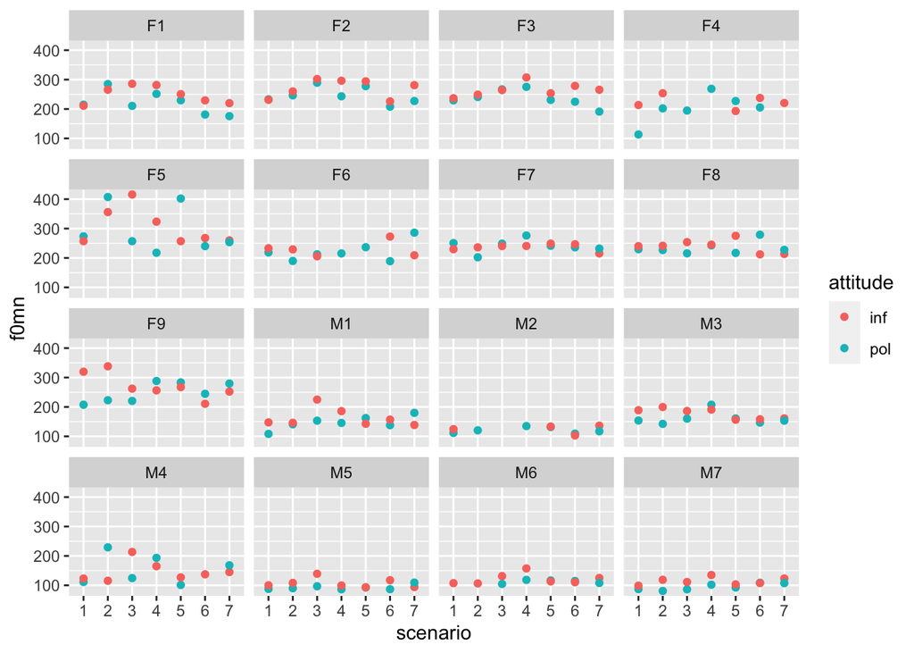

```r
ggplot(politeness, aes(x = scenario, y = f0mn, colour = attitude)) + geom_point()+
  facet_wrap(~subject)
```

There seem to be a lower baseline/intercept given that you’re a male. Attitude doesn’t seem to have an large effect on f0mn. So an idea could be to add Gender as a fixed effect and subject as a random intercept as there is also individual variance within the gender category.

## Exercise 2 - comparison of models

For this part, make sure to have `lme4` installed.  
You can install it using `install.packages("lme4")` and load it using `library(lme4)`  
`lmer` is used for multilevel modelling

```r
mixed.model <- lmer(f0mn ~ scenario + gender + (1|subject), data=politeness)
```

1. Build four models and do some comparisons
   1. a single level model that models *f0mn* as dependent on *gender*

```r
m3.1 <- lm(f0mn ~ gender, data = politeness)
```

```
ii. a two-level model that adds a second level on top of i. where unique intercepts are modelled for each _scenario_
```

```r
m3.2 <- lmer(f0mn ~ gender + (1|scenario), data = politeness, REML = F)
```

```
iii. a two-level model that only has _subject_ as an intercept
```

```r
m3.3 <- lmer(f0mn ~ gender + (1|subject), data = politeness, REML = F)
summary(m3.3)
```

```
## Linear mixed model fit by maximum likelihood . t-tests use Satterthwaite's
##   method [lmerModLmerTest]
## Formula: f0mn ~ gender + (1 | subject)
##    Data: politeness
##
##      AIC      BIC   logLik deviance df.resid
##   2112.0   2125.5  -1052.0   2104.0      208
##
## Scaled residuals:
##     Min      1Q  Median      3Q     Max
## -3.2405 -0.5471 -0.1431  0.4360  3.8443
##
## Random effects:
##  Groups   Name        Variance Std.Dev.
##  subject  (Intercept)  511.2   22.61
##  Residual             1026.7   32.04
## Number of obs: 212, groups:  subject, 16
##
## Fixed effects:
##             Estimate Std. Error       df t value Pr(>|t|)
## (Intercept)  246.547      8.083   15.984  30.501 1.36e-15 ***
## genderM     -115.193     12.239   16.076  -9.412 6.08e-08 ***
## ---
## Signif. codes:  0 '***' 0.001 '**' 0.01 '*' 0.05 '.' 0.1 ' ' 1
##
## Correlation of Fixed Effects:
##         (Intr)
## genderM -0.660
```

```
iv. a two-level model that models intercepts for both _scenario_ and _subject_
```

```r
m3.4 <- lmer(f0mn ~ gender + (1|scenario) + (1|subject), data = politeness, REML = F)
summary(m3.4)
```

```
## Linear mixed model fit by maximum likelihood . t-tests use Satterthwaite's
##   method [lmerModLmerTest]
## Formula: f0mn ~ gender + (1 | scenario) + (1 | subject)
##    Data: politeness
##
##      AIC      BIC   logLik deviance df.resid
##   2105.2   2122.0  -1047.6   2095.2      207
##
## Scaled residuals:
##     Min      1Q  Median      3Q     Max
## -3.0357 -0.5384 -0.1177  0.4346  3.7808
##
## Random effects:
##  Groups   Name        Variance Std.Dev.
##  subject  (Intercept) 516.19   22.720
##  scenario (Intercept)  89.36    9.453
##  Residual             940.25   30.664
## Number of obs: 212, groups:  subject, 16; scenario, 7
##
## Fixed effects:
##             Estimate Std. Error       df t value Pr(>|t|)
## (Intercept)  246.778      8.829   19.248  27.952  < 2e-16 ***
## genderM     -115.186     12.223   16.011  -9.424 6.19e-08 ***
## ---
## Signif. codes:  0 '***' 0.001 '**' 0.01 '*' 0.05 '.' 0.1 ' ' 1
##
## Correlation of Fixed Effects:
##         (Intr)
## genderM -0.604
```

```
v. which of the models has the lowest residual standard deviation, also compare the Akaike Information Criterion `AIC`?
```

```r
#Calculate Residual Standard Deivation
c(S_res1 = sqrt(sum(resid(m3.1)^2)/(nrow(politeness)-2)),
S_res2 = sqrt(sum(resid(m3.2)^2)/(nrow(politeness)-2)),
S_res3 = sqrt(sum(resid(m3.3)^2)/(nrow(politeness)-2)),
S_res4 = sqrt(sum(resid(m3.4)^2)/(nrow(politeness)-2)))
```

```
##   S_res1   S_res2   S_res3   S_res4
## 38.38130 37.10991 30.27006 28.62566
```

```r
#Compare AIC
AIC(m3.1,m3.2,m3.3,m3.4)
```

|  | df | AIC |
| --- | --- | --- |
| m3.1 | 3 | 2163.971 |
| m3.2 | 4 | 2162.257 |
| m3.3 | 4 | 2112.048 |
| m3.4 | 5 | 2105.176 |

m3.4 is the model with the lowest residual standard deviation and also performs the best following the AIC.

```
vi. which of the second-level effects explains the most variance?
```

```r
#Anova cannot compare multi-level and single-level models. :(
anova(m3.2,m3.3,m3.4)
```

|  | npar | AIC | BIC | logLik | deviance | Chisq | Df | Pr(>Chisq) |
| --- | --- | --- | --- | --- | --- | --- | --- | --- |
| m3.2 | 4 | 2162.257 | 2175.684 | -1077.129 | 2154.257 | NA | NA | NA |
| m3.3 | 4 | 2112.048 | 2125.474 | -1052.024 | 2104.048 | 50.209453 | 0 | NA |
| m3.4 | 5 | 2105.176 | 2121.958 | -1047.588 | 2095.176 | 8.872474 | 1 | 0.002895025 |

```r
#Look for varaince explained
MuMIn::r.squaredGLMM(m3.2)
```

```
##            R2m       R2c
## [1,] 0.6817304 0.6965456
```

```r
MuMIn::r.squaredGLMM(m3.3)
```

```
##            R2m       R2c
## [1,] 0.6798832 0.7862932
```

```r
MuMIn::r.squaredGLMM(m3.4)
```

```
##            R2m       R2c
## [1,] 0.6787423 0.8045921
```

M3.2 (f0mn ~ gender + (1|scenario)) showed the best variance explained purely by fixed effects. But m3.4 (f0mn ~ gender + (1|scenario) + (1|subject)) showed most explained variance with 80% of the variance being accounted for from both fixed and random effects.

We can also conclude that adding subject as random intercept rather than scenario explains more of the variance but also has more shared variance with our fixed effect gender.

2. Why is our single-level model bad?
   1. create a new data frame that has three variables, *subject*, *gender* and *f0mn*, where *f0mn* is the average of all responses of each subject, i.e. averaging across *attitude* and_scenario_

```r
politeness_sel <- politeness %>%
  filter(!is.na(f0mn)) %>%
  group_by(subject) %>%
  summarise(f0mn = mean(f0mn))

politeness_sel <- politeness_sel %>%
  mutate(gender = if_else(grepl("F", politeness_sel$subject, ignore.case = T),"F","M")) %>%
  mutate(gender = as.factor(gender))
```

```
ii. build a single-level model that models _f0mn_ as dependent on _gender_ using this new dataset
```

```r
m4.1 <- lm(f0mn ~ gender, data = politeness_sel)
```

[output not shown]

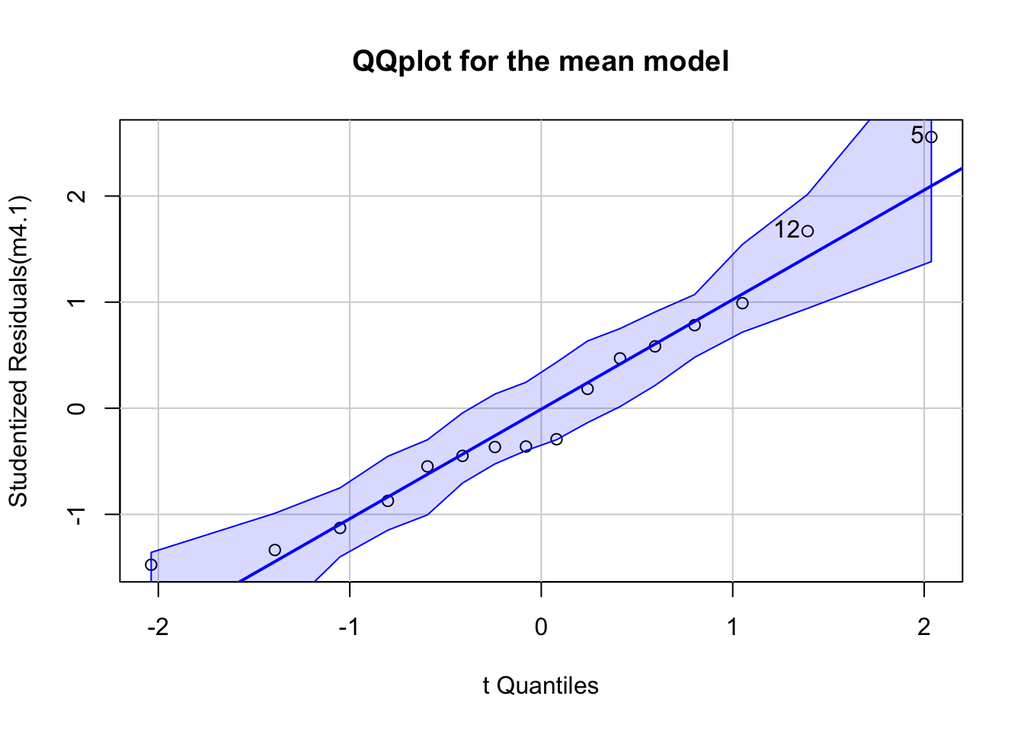

```
## [1]  5 12
```

```r
#qqPlot
car::qqPlot(m4.1, main = "QQplot for the mean model")
```

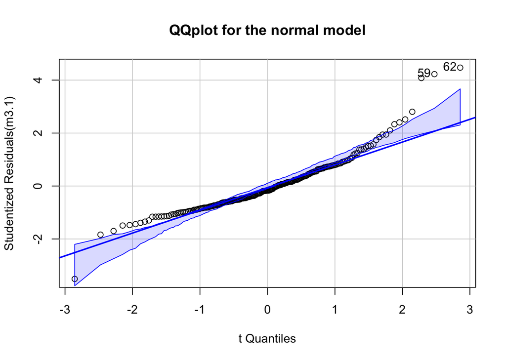

```
## [1] 59 62
```

```r
car::qqPlot(m3.1, main = "QQplot for the normal model")
```

```
iv. Also make a quantile-quantile plot for the residuals of the  multilevel model with two intercepts. Does it look alright?
```

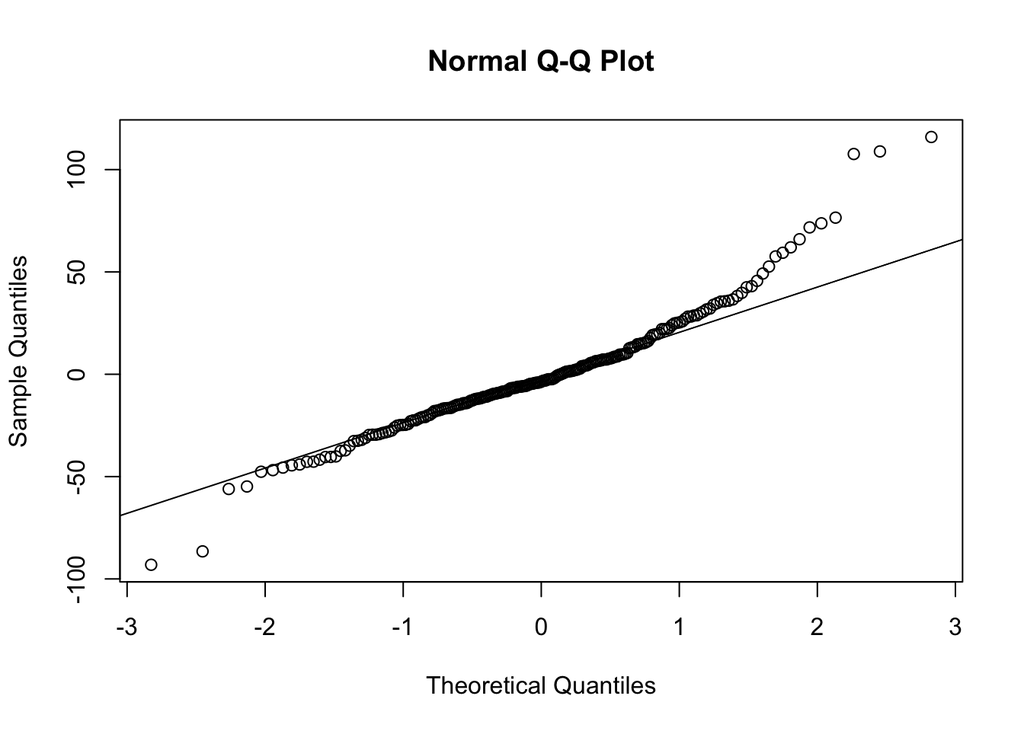

```r
#car::qqPlot doesn't like mixed effect models so we do it like this.
qqnorm(resid(m3.4))
qqline(resid(m3.4))
```

3. Plotting the two-intercepts model
   1. Create a plot for each subject, (similar to part 3 in Exercise 1), this time also indicating the fitted value for each of the subjects for each for the scenarios (hint use `fixef` to get the “grand effects” for each gender and `ranef` to get the subject- and scenario-specific effects)

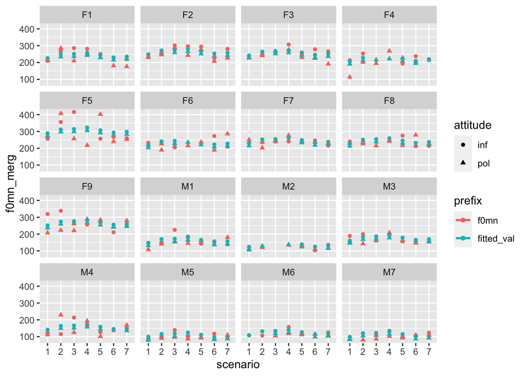

```r
politeness_fil <- politeness %>%  #Remove NA's
    filter(!is.na(f0mn))

m3.5<- lmer(f0mn ~ scenario + attitude + (1|subject), data = politeness_fil)#new fit

politeness_fit <- politeness_fil %>% #Create data frame with fitted and actual values.
  mutate(fitted_val = fitted.values(m3.5)) %>%
  pivot_longer(cols = c(f0mn,fitted_val) , names_to = "prefix", values_to = "f0mn_merg")


ggplot(politeness_fit, aes(x = scenario, y = f0mn_merg, colour = prefix, shape = attitude)) + geom_point() + geom_smooth(method = "lm", se = F) +facet_wrap(~subject)
```

## Exercise 3 - now with attitude

1. Carry on with the model with the two unique intercepts fitted (*scenario* and *subject*).
   1. now build a model that has *attitude* as a main effect besides *gender*

```r
m5.1 <- lmer(f0mn ~ attitude + gender + (1|subject) + (1|scenario), data = politeness, REML = F)
```

```
ii. make a separate model that besides the main effects of _attitude_ and _gender_ also include their interaction
```

```r
m5.2 <- lmer(f0mn ~ attitude*gender + (1|subject)+ (1|scenario), data = politeness, REML = F)
```

```
iii. describe what the interaction term in the model says about Korean men's pitch when they are polite relative to Korean women's pitch when they are polite (you don't have to judge whether it is interesting)
```

```r
summary(m5.2)
```

```
## Linear mixed model fit by maximum likelihood . t-tests use Satterthwaite's
##   method [lmerModLmerTest]
## Formula: f0mn ~ attitude * gender + (1 | subject) + (1 | scenario)
##    Data: politeness
##
##      AIC      BIC   logLik deviance df.resid
##   2096.0   2119.5  -1041.0   2082.0      205
##
## Scaled residuals:
##     Min      1Q  Median      3Q     Max
## -2.8460 -0.5893 -0.0685  0.3946  3.9518
##
## Random effects:
##  Groups   Name        Variance Std.Dev.
##  subject  (Intercept) 514.09   22.674
##  scenario (Intercept)  99.08    9.954
##  Residual             876.46   29.605
## Number of obs: 212, groups:  subject, 16; scenario, 7
##
## Fixed effects:
##                     Estimate Std. Error       df t value Pr(>|t|)
## (Intercept)          255.632      9.289   23.556  27.521  < 2e-16 ***
## attitudepol          -17.198      5.395  190.331  -3.188  0.00168 **
## genderM             -118.251     12.841   19.922  -9.209 1.28e-08 ***
## attitudepol:genderM    5.563      8.241  190.388   0.675  0.50049
## ---
## Signif. codes:  0 '***' 0.001 '**' 0.01 '*' 0.05 '.' 0.1 ' ' 1
##
## Correlation of Fixed Effects:
##             (Intr) atttdp gendrM
## attitudepol -0.299
## genderM     -0.605  0.216
## atttdpl:gnM  0.195 -0.654 -0.323
```

```r
MuMIn::r.squaredGLMM(m5.2)
```

```
##            R2m       R2c
## [1,] 0.6904904 0.8178935
```

```r
levels(politeness$gender)
```

```
## [1] "F" "M"
```

```r
levels(politeness$attitude)
```

```
## [1] "inf" "pol"
```

2. Compare the three models (1. gender as a main effect; 2. gender and attitude as main effects; 3. gender and attitude as main effects and the interaction between them. For all three models model unique intercepts for *subject* and *scenario*) using residual variance, residual standard deviation and AIC.

```r
#reidual variance
c(RS_5.2 = sum(residuals(m5.2)^2),
RS_5.1 = sum(residuals(m5.1)^2),
RS_3.4 = sum(residuals(m3.4)^2))
```

```
##   RS_5.2   RS_5.1   RS_3.4
## 169305.6 169681.1 181913.0
```

```r
#residual standard deviation
c(S_res5.2 = sqrt(sum(resid(m5.2)^2)/(nrow(politeness)-2)),
S_res5.1 = sqrt(sum(resid(m5.2)^2)/(nrow(politeness)-2)),
S_res3.4 = sqrt(sum(resid(m3.4)^2)/(nrow(politeness)-2)))
```

```
## S_res5.2 S_res5.1 S_res3.4
## 27.61590 27.61590 28.62566
```

```r
anova(m3.4, m5.1, m5.2)
```

|  | npar | AIC | BIC | logLik | deviance | Chisq | Df | Pr(>Chisq) |
| --- | --- | --- | --- | --- | --- | --- | --- | --- |
| m3.4 | 5 | 2105.176 | 2121.958 | -1047.588 | 2095.176 | NA | NA | NA |
| m5.1 | 6 | 2094.489 | 2114.628 | -1041.244 | 2082.489 | 12.6867631 | 1 | 0.0003682532 |
| m5.2 | 7 | 2096.034 | 2119.530 | -1041.017 | 2082.034 | 0.4551491 | 1 | 0.4998998177 |

3. Choose the model that you think describe the data the best - and write a short report on the main findings based on this model. At least include the following:
1. describe what the dataset consists of
2. what can you conclude about the effect of gender and attitude on pitch (if anything)?
3. motivate why you would include separate intercepts for subjects and scenarios (if you think they should be included)
4. describe the variance components of the second level (if any)
5. include a Quantile-Quantile plot of your chosen model

# My answer to all of the above

```r
summary(m5.1)
```

```
## Linear mixed model fit by maximum likelihood . t-tests use Satterthwaite's
##   method [lmerModLmerTest]
## Formula: f0mn ~ attitude + gender + (1 | subject) + (1 | scenario)
##    Data: politeness
##
##      AIC      BIC   logLik deviance df.resid
##   2094.5   2114.6  -1041.2   2082.5      206
##
## Scaled residuals:
##     Min      1Q  Median      3Q     Max
## -2.8791 -0.5968 -0.0569  0.4260  3.9068
##
## Random effects:
##  Groups   Name        Variance Std.Dev.
##  subject  (Intercept) 514.92   22.692
##  scenario (Intercept)  99.22    9.961
##  Residual             878.39   29.638
## Number of obs: 212, groups:  subject, 16; scenario, 7
##
## Fixed effects:
##             Estimate Std. Error       df t value Pr(>|t|)
## (Intercept)  254.408      9.117   21.800  27.904  < 2e-16 ***
## attitudepol  -14.817      4.086  190.559  -3.626 0.000369 ***
## genderM     -115.447     12.161   16.000  -9.494 5.63e-08 ***
## ---
## Signif. codes:  0 '***' 0.001 '**' 0.01 '*' 0.05 '.' 0.1 ' ' 1
##
## Correlation of Fixed Effects:
##             (Intr) atttdp
## attitudepol -0.231
## genderM     -0.583  0.006
```

```r
MuMIn::r.squaredGLMM(m5.1)
```

```
##            R2m       R2c
## [1,] 0.6899193 0.8175096
```

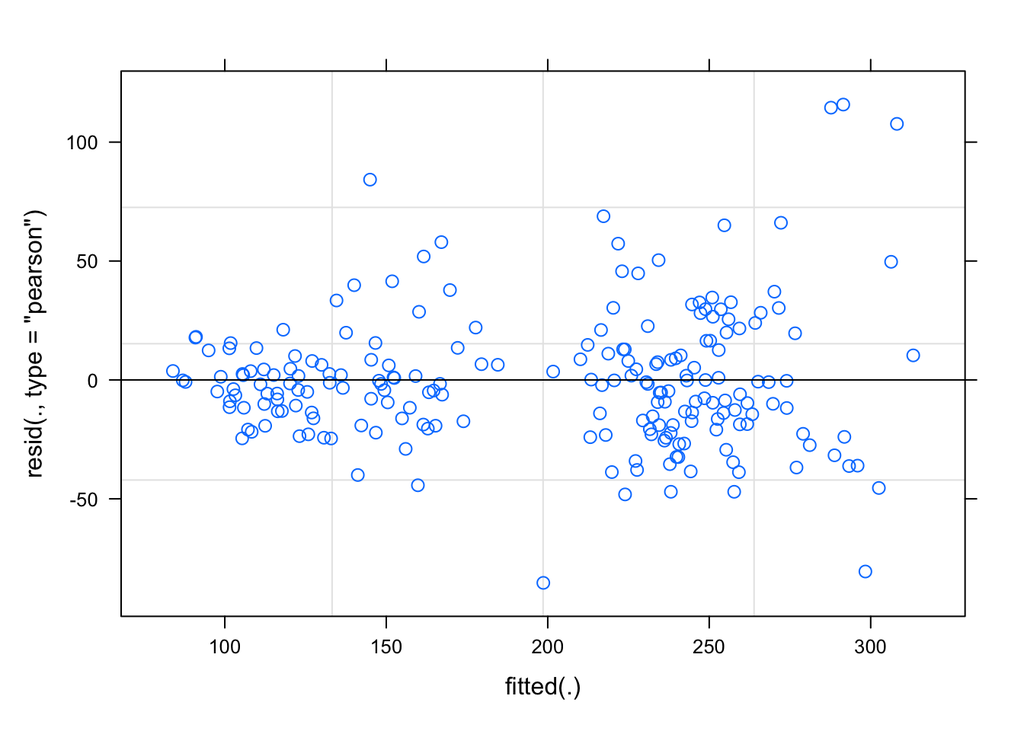

```r
#check assumptions
plot(m5.1)
```

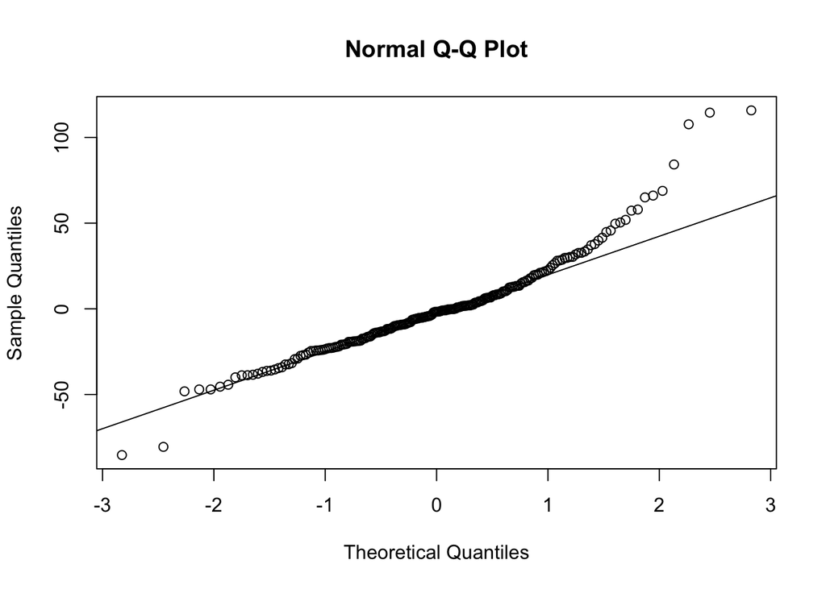

```r
qqnorm(resid(m5.1))
qqline(resid(m5.1))
```

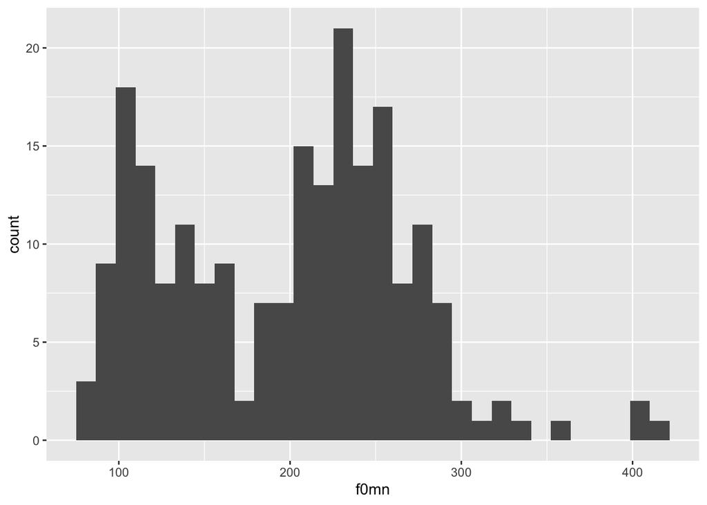

```r
ggplot(politeness, aes(x= f0mn)) + geom_histogram()
```

“We used R (R Core Team, 2019) and lmerTest (Kuznetsova, Brockhoff and Christensen, 2017) to perform a linear mixed effects analysis of the relationship between f0mn, gender and attitude. As random effects, we had intercepts for subjects, and scenario.

Both fixed and random effects accounted for roughly 82% of the variance in the f0mn variable with random effects proportion being 12.7%. Visual inspection shows that both the qqplot and histogram violates the assumption of a mixed effect linear model. The more robust generalized mixed effect model with a link function would be preferred. But as did was not the task such model was not constructed.

f0mn was found to be significantly modulated by gender. $\beta_2 = -115, SE = 12.16, p<0.05$ Attitude also showed a significant modulating of f0mn $\beta_1 = -14.8, SE = 4, p<0.05$